# IF540_Kelas EL_00000054804_Christopher Darren_Week09

## TUGAS LAB IF540 MACHINE LEARNING

### WEEK 09 : Algoritma Partisi

#### Semester Genap 2022/2023

```python
# Run this code when you restart the machine
# Fill in with YOUR name and NIM
import datetime
import uuid

myName = "Christopher Darren"
myNIM = "00000054804"
```

```python
myDate = datetime.datetime.now()
myDevice = str(uuid.uuid1())

print("Name: \t\t{}".format(myName))
print("NIM: \t\t{}".format(myNIM))
print("Start: \t\t{}".format(myDate))
print("Device ID: \t{}".format(myDevice))
```

```
Name: 		Christopher Darren
NIM: 		00000054804
Start: 		2023-04-27 08:19:58.509341
Device ID: 	a0132b25-e499-11ed-be06-f02f74a116e8
```

### Dataset yang dipakai:

1. Vector Dataset – sumber : https://www.kaggle.com/datasets/donfuzius/vectordigits (KMeans, Kmedoids) apa itu vector dataset? dataset ini intinya mengenai handwritten digits yang dibuat oleh seorang Ayah untuk anaknya yang akan belajar multiplikasi menggunakan iphone.dataset ini terdiri dari 41 columns, dan 400 rows.
2. Adult Income – sumber : https://www.kaggle.com/datasets/vivamoto/us-adult-income-update (Kmodes) apa isi dataset ini? dataset ini mengenai Prediction task is to determine whether a person makes over 50K a year from the analysis of 13 predictors. sederhananya adalah dataset ini berisi mengenai pendapatan income orang dewasa di berbagai negara. dataset ini terdiri dari 15 columns, dan 48842 rows(ini setelah di filter)

### K-Means Clustering

#### Many clustering algorithms are available in Scikit-Learn and elsewhere, but perhaps the simplest to understand is an algorithm known as k means clustering, which is implemented in sklearn.cluster.KMeans.

#### 1. We begin with standard imports :

```python
%matplotlib inline
import matplotlib.pyplot as plt
import seaborn as sns; sns.set() #for plot styling
import numpy as np

import pandas as pd
```

#### 2. First, lets generate a two-dimensional dataset containing four distinct blobs. To emphasize that this is an unsupervised algorithm, we will leave the labels out the visualization :

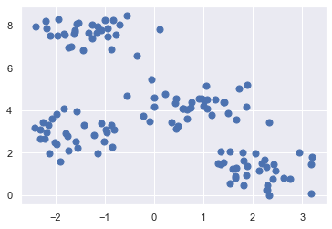

```python
from sklearn.datasets import make_blobs
X, y_true = make_blobs(n_samples=130, centers=4,
                      cluster_std=0.60, random_state=0)
plt.scatter(X[:, 0], X[:, 1], s=50);
```

#### 3. By eye, it is relatively easy to pick out the four clusters. The k-means algorithm does this automatically and in Scikit-Learn uses the typical estimator API

```python
from sklearn.cluster import KMeans
kmeans = KMeans(n_clusters=4)
kmeans.fit(X)
y_kmeans = kmeans.predict(X)
```

#### 4. Lets visualize the result by plotting the data colored by these labels. We will also plot the cluster centers as determined by the k-means estimator:

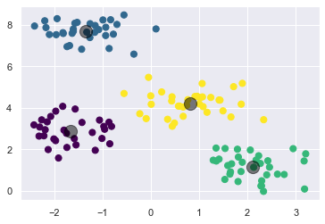

```python
plt.scatter(X[:, 0], X[:, 1], c=y_kmeans, s=50, cmap='viridis')

centers = kmeans.cluster_centers_
plt.scatter(centers[:, 0], centers[:, 1], c='black', s=200, alpha=0.5);
```

#### 5. The k-Means algorithm is simple enough that we can write it in a few lines of code. The following is a very basic implementation:

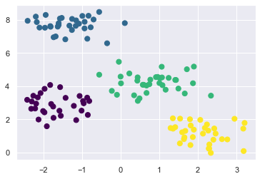

```python
from sklearn.metrics import pairwise_distances_argmin

def find_clusters(X, n_clusters, rseed=2):
    rng = np.random.RandomState(rseed)
    i = rng.permutation(X.shape[0])[:n_clusters]
    centers = X[i]

    while True:
        # a. Assign labels based on closest center
        labels = pairwise_distances_argmin(X, centers)
        new_centers = np.array([X[labels == i].mean(0)
                               for i in range(n_clusters)])

        # b. Find new centers from means of points
        if np.all(centers == new_centers):
            break

        # c. Check for convergence
        centers = new_centers

    return centers, labels

centers, labels = find_clusters(X, 4)
plt.scatter(X[:, 0], X[:, 1], c=labels,
            s=50, cmap='viridis');
```

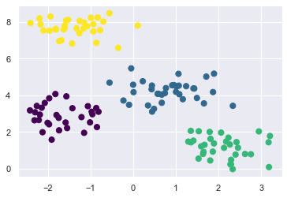

```python
centers, labels = find_clusters(X, 4, rseed=0)
plt.scatter(X[:, 0], X[:, 1], c=labels,
            s=50, cmap='viridis');
```

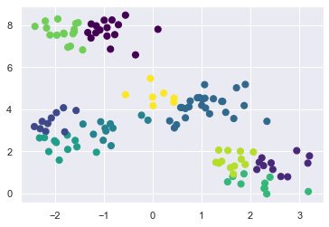

```python
#saya coba 10 cluster
labels = KMeans(10, random_state=0).fit_predict(X)
plt.scatter(X[:, 0], X[:, 1], c=labels,
           s=50, cmap='viridis');
```

#### 8. In particular, the boundaries between k-means cluster will always be linear, which means that it will fail for more complicated boundaries. Consider the following data, along with the cluster labels found by the typical k-means approach ;

```python
from sklearn.datasets import make_moons
X, y = make_moons(700, noise=.05, random_state=0)
```

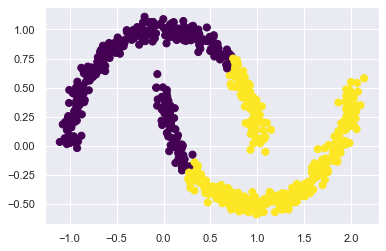

```python
labels = KMeans(2, random_state=0).fit_predict(X)
plt.scatter(X[:, 0],X[:,1], c=labels,
           s=50, cmap='viridis')
```

#### 9. One version of this kernelized k-means is implemented in Scikit-Learn within the SpectralClustering estimator. It uses the graph of nearest neighbors to compute a higher-dimensional representation of the data, and then assigns labels using a k-means algorithm:

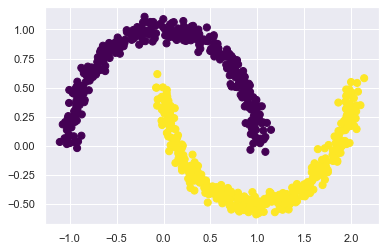

```python
from sklearn.cluster import SpectralClustering
model = SpectralClustering(n_clusters=2, affinity='nearest_neighbors',
                          assign_labels='kmeans')
labels = model.fit_predict(X)
plt.scatter(X[:, 0], X[:, 1], c=labels,
           s=50, cmap='viridis');
```

#### 10. IMPORTING OWN DATASET

```python
number= pd.read_csv(r"D:\SEMESTER 4\IF540 Machine Learning\LAB\week9\Training.csv")
number.head(5)
```

|  | label | v1_x | v1_y | v2_x | v2_y | v3_x | v3_y | v4_x | v4_y | v5_x | ... | v16_x | v16_y | v17_x | v17_y | v18_x | v18_y | v19_x | v19_y | v20_x | v20_y |
| --- | --- | --- | --- | --- | --- | --- | --- | --- | --- | --- | --- | --- | --- | --- | --- | --- | --- | --- | --- | --- | --- |
| 0 | 2 | 0 | 0 | -2 | -4 | 4 | -3 | 7 | -3 | 5 | ... | 6 | -1 | 5 | -1 | 4 | 0 | 3 | 0 | 1 | 0 |
| 1 | 5 | 0 | 0 | 1 | 6 | 0 | 5 | 0 | 1 | 0 | ... | 0 | 0 | 0 | 0 | 2 | 0 | 8 | 0 | 4 | -2 |
| 2 | 1 | 0 | 0 | 1 | -1 | 3 | -3 | 5 | -5 | 6 | ... | -1 | 7 | 0 | 6 | 0 | 5 | 0 | 7 | 1 | 1 |
| 3 | 9 | -8 | -1 | -7 | 5 | -5 | 5 | -1 | 4 | 3 | ... | -3 | 4 | -4 | 1 | -4 | 0 | -2 | 0 | -2 | -3 |
| 4 | 7 | 6 | -1 | 8 | -2 | 6 | -1 | 3 | 0 | 1 | ... | 3 | 0 | 5 | 0 | 5 | 0 | 3 | 0 | 2 | -1 |

5 rows × 41 columns

#### Data preprocessing

```python
number.info()
```

```
<class 'pandas.core.frame.DataFrame'>
RangeIndex: 400 entries, 0 to 399
Data columns (total 41 columns):
 #   Column  Non-Null Count  Dtype
---  ------  --------------  -----
 0   label   400 non-null    int64
 1   v1_x    400 non-null    int64
 2   v1_y    400 non-null    int64
 3   v2_x    400 non-null    int64
 4   v2_y    400 non-null    int64
 5   v3_x    400 non-null    int64
 6   v3_y    400 non-null    int64
 7   v4_x    400 non-null    int64
 8   v4_y    400 non-null    int64
 9   v5_x    400 non-null    int64
```

[output cut: 33 more lines]

```python
number.shape
```

```
(400, 41)
```

```python
#checking null values
number.isnull().sum()
```

```
label    0
v1_x     0
v1_y     0
v2_x     0
v2_y     0
v3_x     0
v3_y     0
v4_x     0
v4_y     0
v5_x     0
v5_y     0
v6_x     0
v6_y     0
v7_x     0
v7_y     0
v8_x     0
v8_y     0
v9_x     0
v9_y     0
v10_x    0
v10_y    0
v11_x    0
v11_y    0
v12_x    0
v12_y    0
v13_x    0
v13_y    0
v14_x    0
v14_y    0
v15_x    0
v15_y    0
v16_x    0
v16_y    0
v17_x    0
v17_y    0
v18_x    0
v18_y    0
v19_x    0
v19_y    0
v20_x    0
v20_y    0
dtype: int64
```

```python
#checking duplicate values
number.duplicated()
```

```
0      False
1      False
2      False
3      False
4      False
       ...
395    False
396    False
397    False
398    False
399    False
Length: 400, dtype: bool
```

```python
number.duplicated().sum()
```

```
0
```

```python
X = number.iloc[:, :-1].values
y = number.iloc[:, -1].values
```

```python
X
```

```
array([[ 2,  0,  0, ...,  3,  0,  1],
       [ 5,  0,  0, ...,  8,  0,  4],
       [ 1,  0,  0, ...,  0,  7,  1],
       ...,
       [ 5,  0,  2, ...,  3, -1,  3],
       [ 4,  0,  4, ...,  6,  0,  1],
       [ 3,  3, -8, ..., -9,  1, -7]], dtype=int64)
```

#### 11. The clustering can be performed as we did before:

```python
from sklearn.datasets import load_digits
digits = X
digits.data.shape
```

```
(400, 40)
```

```python
kmeans = KMeans(n_clusters=10, random_state=0)
clusters = kmeans.fit_predict(digits.data)
kmeans.fit(X)
```

```
KMeans(n_clusters=10, random_state=0)
```

```python
centers = kmeans.cluster_centers_
```

```python
centers.shape
```

```
(10, 40)
```

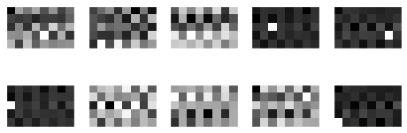

```python
fig, ax = plt.subplots(2, 5, figsize=(8, 3))
centers = kmeans.cluster_centers_.reshape(10, 5, 8 )
for axi, center in zip(ax.flat, centers):
    axi.set(xticks=[], yticks=[])
    axi.imshow(center, interpolation='nearest',cmap=plt.cm.binary)
```

```python
digits = digits.reshape(digits.shape[0], -1)
```

#### 13. Because k-means knows nothing about the identity of the cluster, the 0–9 labels may be permuted. We can fix this by matching each learned cluster label with the true labels found in them:

```python
from scipy.stats import mode

labels = np.zeros_like(clusters)
for i in range(10):
    mask = (clusters == i)
    flat_mask = mask.flatten()
    mode_value = mode(digits[mask.reshape(-1), :])[0].ravel()[0]
    labels[flat_mask] = mode_value
```

```python
from sklearn.datasets import load_digits
from sklearn.model_selection import train_test_split
from sklearn.svm import SVC

digits = X

# get the features and target labels
#X, y = digits.data, digits.target
# split the dataset into training and testing sets
X_train, X_test, y_train, y_test = train_test_split(X, y, test_size=0.2, random_state=42)

# train your model on the training set
model = SVC()
model.fit(X_train, y_train)

# evaluate your model on the testing set
accuracy = model.score(X_test, y_test)
print("Accuracy Score:", accuracy)
```

```
Accuracy Score: 0.3625
```

#### 15. Confusion Matrix

[figure not shown]

```python
import seaborn as sns
from sklearn.metrics import confusion_matrix
import matplotlib.pyplot as plt

# Get predictions from your model on the test set
y_pred = model.predict(X_test)

# Compute the confusion matrix
mat = confusion_matrix(y_test, y_pred)

# Plot the confusion matrix using seaborn and matplotlib
sns.heatmap(mat.T, square=True, annot=True, fmt='d', cbar=False,
            xticklabels=digits,
            yticklabels=digits)
plt.xlabel('true label')
plt.ylabel('predicted label')
plt.show()
```

#### 16. The image shown in the following figure, which is from scikit-learn datasets module (note : this requires the “pillow” package to be installed):

[figure not shown]

```python
from sklearn.datasets import load_sample_image
yuan = load_sample_image("wwg.jpg")
ax = plt.axes(xticks=[], yticks=[])
ax.imshow(yuan)
```

#### 17. The image itself is stored in a three-dimensional array of size (height, width, RGB), containing red/blue/green contributions as integers from 0 to 255:

```python
yuan.shape
```

```
(1080, 1920, 3)
```

#### 18. One way we can view this set of pixels is as a cloud of points in a three-dimensional color space. We will reshape the data to [n_samples x n_features], and rescale the colors so that they lie between 0 and 1:

```python
data = yuan / 255.0
data = data.reshape(1080 * 1920, 3)
data.shape
```

```
(2073600, 3)
```

#### 19. We can visualize these pixels in this color space, using a subset of 10,000 pixels for efficiency:

```python
def plot_pixels(data,title, colors=None, N=10000):
    if colors is None:
        colors = data

        # choose a random subset
        rng = np.random.RandomState(0)
        i = rng.permutation(data.shape[0])[:N]
        colors = colors[i]
        R, G, B = data[i].T

        fig, ax = plt.subplots(1, 2, figsize=(16, 6))
        ax[0].scatter(R, G, color=colors, marker='.')
        ax[0].set(xlabel='Red', ylabel='Green', xlim=(0, 1), ylim=(0, 1))

        ax[1].scatter(R, B, color=colors, marker='.')
        ax[1].set(xlabel='Red', ylabel='Blue', xlim=(0, 1), ylim=(0, 1))

        fig.suptitle(title, size=20);
```

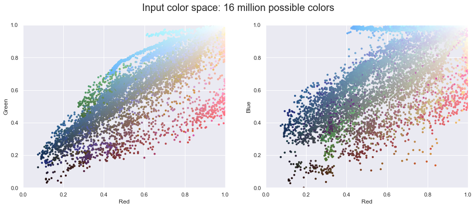

```python
plot_pixels(data, title='Input color space: 16 million possible colors')
```

#### 20. Reduce 16 millions color to 16 colors

```python
import warnings; warnings.simplefilter('ignore')

from sklearn.cluster import MiniBatchKMeans
kmeans = MiniBatchKMeans(16)
kmeans.fit(data)
new_colors = kmeans.cluster_centers_[kmeans.predict(data)]

#plot_pixels(data, title='')
plot_pixels(data, colors=new_colors,title="Reduced color space: 16 colors")
```

[output not shown]

#### 21. Result of Original vs Recolor

[figure not shown]

```python
yuan_recolored = new_colors.reshape(yuan.shape)

fig, ax = plt.subplots(1, 2, figsize=(16, 6),
                      subplot_kw=dict(xticks=[], yticks=[]))
fig.subplots_adjust(wspace=0.05)
ax[0].imshow(yuan)
ax[0].set_title('Original Image', size=16)
ax[1].imshow(yuan_recolored)
ax[1].set_title('16-color Image', size=16);
```

### K-Medoids Algorithm

#### 22. For the beginning, we import the important libraries :

```python
#Imports
import pandas as pd
import numpy as np
import matplotlib.pyplot as plt
from mpl_toolkits.mplot3d import Axes3D
from sklearn import datasets
from sklearn.decomposition import PCA
```

#### 23. Import data

```python
data = number.copy()
data.head(5)
```

|  | label | v1_x | v1_y | v2_x | v2_y | v3_x | v3_y | v4_x | v4_y | v5_x | ... | v16_x | v16_y | v17_x | v17_y | v18_x | v18_y | v19_x | v19_y | v20_x | v20_y |
| --- | --- | --- | --- | --- | --- | --- | --- | --- | --- | --- | --- | --- | --- | --- | --- | --- | --- | --- | --- | --- | --- |
| 0 | 2 | 0 | 0 | -2 | -4 | 4 | -3 | 7 | -3 | 5 | ... | 6 | -1 | 5 | -1 | 4 | 0 | 3 | 0 | 1 | 0 |
| 1 | 5 | 0 | 0 | 1 | 6 | 0 | 5 | 0 | 1 | 0 | ... | 0 | 0 | 0 | 0 | 2 | 0 | 8 | 0 | 4 | -2 |
| 2 | 1 | 0 | 0 | 1 | -1 | 3 | -3 | 5 | -5 | 6 | ... | -1 | 7 | 0 | 6 | 0 | 5 | 0 | 7 | 1 | 1 |
| 3 | 9 | -8 | -1 | -7 | 5 | -5 | 5 | -1 | 4 | 3 | ... | -3 | 4 | -4 | 1 | -4 | 0 | -2 | 0 | -2 | -3 |
| 4 | 7 | 6 | -1 | 8 | -2 | 6 | -1 | 3 | 0 | 1 | ... | 3 | 0 | 5 | 0 | 5 | 0 | 3 | 0 | 2 | -1 |

5 rows × 41 columns

#### 24.Scaling Data

```python
#scaling
from sklearn.preprocessing import MinMaxScaler
scaler = MinMaxScaler()
data = pd.DataFrame(scaler.fit_transform(data), columns=data.columns)
data.head(5)
```

|  | label | v1_x | v1_y | v2_x | v2_y | v3_x | v3_y | v4_x | v4_y | v5_x | ... | v16_x | v16_y | v17_x | v17_y | v18_x | v18_y | v19_x | v19_y | v20_x | v20_y |
| --- | --- | --- | --- | --- | --- | --- | --- | --- | --- | --- | --- | --- | --- | --- | --- | --- | --- | --- | --- | --- | --- |
| 0 | 0.222222 | 0.625 | 0.5000 | 0.315789 | 0.1250 | 0.60 | 0.285714 | 0.777778 | 0.333333 | 0.666667 | ... | 0.666667 | 0.64 | 0.750000 | 0.666667 | 0.681818 | 0.352941 | 0.60 | 0.363636 | 0.5625 | 0.6 |
| 1 | 0.555556 | 0.625 | 0.5000 | 0.473684 | 0.7500 | 0.40 | 0.666667 | 0.388889 | 0.523810 | 0.333333 | ... | 0.444444 | 0.66 | 0.541667 | 0.688889 | 0.590909 | 0.352941 | 0.85 | 0.363636 | 0.7500 | 0.4 |
| 2 | 0.111111 | 0.625 | 0.5000 | 0.473684 | 0.3125 | 0.55 | 0.285714 | 0.666667 | 0.238095 | 0.733333 | ... | 0.407407 | 0.80 | 0.541667 | 0.822222 | 0.500000 | 0.647059 | 0.45 | 1.000000 | 0.5625 | 0.7 |
| 3 | 1.000000 | 0.125 | 0.4375 | 0.052632 | 0.6875 | 0.15 | 0.666667 | 0.333333 | 0.666667 | 0.533333 | ... | 0.333333 | 0.74 | 0.375000 | 0.711111 | 0.318182 | 0.352941 | 0.35 | 0.363636 | 0.3750 | 0.3 |
| 4 | 0.777778 | 1.000 | 0.4375 | 0.842105 | 0.2500 | 0.70 | 0.380952 | 0.555556 | 0.476190 | 0.400000 | ... | 0.555556 | 0.66 | 0.750000 | 0.688889 | 0.727273 | 0.352941 | 0.60 | 0.363636 | 0.6250 | 0.5 |

5 rows × 41 columns

#### 25. PCA Analysis for visualization

```python
pca = PCA(n_components=3)
principalComponents = pca.fit_transform(data)
PCAdf = pd.DataFrame(data = principalComponents, columns  =['principal component 1',
                                                           'principal component 2', 'principal component 3'])
datapoints = PCAdf.values
m,f = datapoints.shape
k = 3
datapoints
```

```
array([[-0.77288271,  0.27085086, -0.01440563],
       [-0.41393747, -0.56187752, -0.29647365],
       [-0.35147902,  0.68722785, -0.17786382],
       ...,
       [-0.38573381, -0.45043215,  0.05555378],
       [-0.03751068, -0.27239715, -0.51225868],
       [ 0.26225945,  1.01001027,  0.377549  ]])
```

#### 26. Visualize on a 3-D Plane

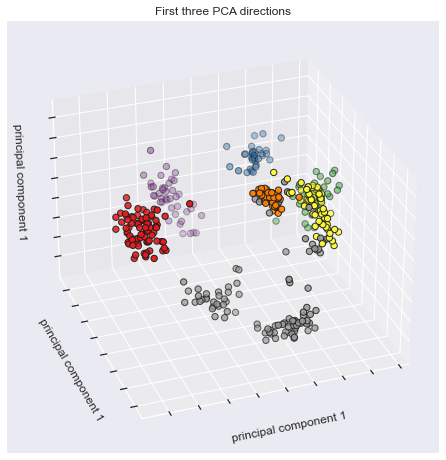

```python
#Visualization
fig = plt.figure(1, figsize=(8, 6))
ax = Axes3D(fig, elev=-150, azim=110)
X_reduced = datapoints
ax.scatter(X_reduced[:, 0], X_reduced[:, 1], X_reduced[:, 2], c=labels,
          cmap=plt.cm.Set1, edgecolor='k', s=40)
ax.set_title("First three PCA directions")
ax.set_xlabel("principal component 1")
ax.w_xaxis.set_ticklabels([])
ax.set_ylabel("principal component 1")
ax.w_yaxis.set_ticklabels([])
ax.set_zlabel("principal component 1")
ax.w_zaxis.set_ticklabels([])
plt.show()
```

#### 27. Medoid Initialization

```python
def init_medoids(X, k):
    from numpy.random import choice
    from numpy.random import seed

    seed(1)
    samples = choice(len(X), size=k, replace=False)
    return X[samples, :]

medoids_initial = init_medoids(datapoints,3)
medoids_initial
```

```
array([[-0.03751068, -0.27239715, -0.51225868],
       [ 0.86920331, -0.15660114, -0.252415  ],
       [ 0.22996824,  1.00636488,  0.44749438]])
```

#### 28. Computing the Distances

```python
def compute_d_p(X, medoids, p):
    m = len(X)
    medoids_shape = medoids.shape
    if len(medoids_shape) ==1:
        medoids = medoids.reshape((1, len(medoids)))
    k = len(medoids)

    S = np.empty((m, k))

    for i in range(m):
        d_i = np.linalg.norm(X[i, :] - medoids, ord=p, axis=1)
        S[i, :] = d_i**p

    return S

S = compute_d_p(datapoints, medoids_initial,2)
S
```

```
array([[1.08374808, 2.93581017, 1.76004253],
       [0.27205919, 1.81264036, 3.42748721],
       [1.1312762 , 2.20767061, 0.83100224],
       ...,
       [0.4753668 , 1.7560486 , 2.65496402],
       [0.        , 0.90305772, 2.62790325],
       [2.52618864, 2.12621769, 0.00594837]])
```

#### 29. Cluster Assignment

```python
def assign_labels(S):
    return np.argmin(S, axis=1)

labels = assign_labels(S)
labels
```

```
array([0, 0, 2, 1, 0, 0, 1, 2, 0, 0, 1, 0, 0, 0, 0, 2, 2, 2, 0, 1, 0, 0,
       0, 0, 1, 0, 1, 0, 0, 0, 2, 0, 1, 0, 0, 1, 0, 0, 0, 0, 1, 0, 0, 1,
       0, 2, 0, 2, 2, 2, 0, 1, 1, 0, 0, 1, 0, 0, 2, 2, 1, 0, 2, 1, 2, 2,
       0, 1, 0, 0, 0, 1, 0, 2, 1, 1, 0, 1, 0, 1, 1, 2, 0, 0, 0, 1, 0, 2,
       0, 0, 1, 2, 2, 0, 2, 0, 0, 0, 2, 1, 2, 1, 0, 0, 2, 1, 1, 2, 0, 0,
       0, 1, 0, 0, 0, 0, 2, 0, 0, 0, 1, 2, 0, 0, 2, 1, 1, 1, 0, 1, 0, 0,
       0, 2, 2, 2, 2, 1, 1, 0, 0, 0, 2, 0, 2, 0, 0, 0, 0, 0, 0, 0, 2, 1,
       2, 1, 0, 2, 0, 0, 2, 0, 0, 2, 2, 0, 2, 0, 1, 2, 0, 2, 1, 0, 0, 0,
       0, 1, 0, 1, 2, 0, 1, 1, 0, 1, 0, 1, 0, 1, 1, 0, 2, 1, 2, 1, 1, 1,
       0, 0, 0, 0, 2, 0, 0, 0, 0, 0, 2, 2, 2, 0, 1, 2, 0, 1, 1, 1, 0, 2,
       0, 0, 0, 1, 0, 0, 0, 0, 0, 0, 0, 0, 2, 1, 1, 1, 2, 1, 1, 0, 0, 2,
       0, 0, 0, 0, 1, 2, 0, 0, 0, 2, 0, 1, 1, 0, 1, 2, 2, 2, 0, 1, 1, 0,
       2, 0, 0, 0, 1, 0, 0, 0, 2, 0, 0, 1, 0, 0, 1, 1, 0, 1, 0, 0, 0, 2,
       2, 1, 0, 1, 1, 0, 0, 2, 0, 2, 0, 0, 0, 0, 1, 0, 0, 1, 0, 1, 0, 0,
       1, 1, 0, 0, 1, 1, 0, 0, 0, 0, 0, 0, 1, 0, 1, 2, 0, 1, 1, 0, 2, 1,
       1, 2, 0, 0, 2, 0, 0, 0, 0, 2, 1, 0, 0, 0, 1, 1, 1, 2, 0, 0, 0, 1,
       0, 0, 1, 2, 0, 0, 2, 0, 2, 0, 0, 1, 0, 1, 0, 0, 2, 2, 0, 1, 0, 1,
       0, 0, 1, 0, 0, 0, 0, 1, 1, 0, 1, 1, 1, 1, 1, 0, 2, 0, 0, 0, 0, 0,
       0, 0, 0, 2], dtype=int64)
```

#### 30. Swap Test

```python
def update_medoids(X, medoids, p):

    S = compute_d_p(datapoints, medoids, p)
    labels = assign_labels(S)

    out_medoids = medoids

    for i in set(labels):

        avg_dissimilarity = np.sum(compute_d_p(datapoints, medoids[i], p))

        cluster_points = datapoints[labels ==1]

        for datap in cluster_points:
            new_medoid = datap
            new_dissimilarity= np.sum(compute_d_p(datapoints, datap, p))

            if new_dissimilarity < avg_dissimilarity:
                avg_dissimilarity = new_dissimilarity

                out_medoids[i] = datap

    return out_medoids
```

```python
def has_converged(old_medoids, medoids):
    return set ([tuple(x) for x in old_medoids]) == set([tuple(x) for x in medoids])
```

#### 32. Putting together

```python
#Full algorithm
def kmedoids(X, k, p, starting_medoids=None, max_steps=np.inf):
    if starting_medoids is None:
        medoids = init_medoids(X,k)
    else:
        medoids = starting_medoids

    converged = False
    labels = np.zeros(len(X))
    i = 1
    while (not converged) and (i <= max_steps):
        old_medoids = medoids.copy()

        S = compute_d_p(X, medoids, p)

        labels = assign_labels(S)

        medoids = update_medoids(X, medoids, p)

        converged = has_converged(old_medoids, medoids)
        i += 1
    return (medoids, labels)

results = kmedoids(datapoints, 3, 2)
final_medoids = results[0]
data['clusters'] = results[1]
print(results)
```

```
(array([[ 0.19548945, -0.14720234,  0.47559038],
       [ 0.19548945, -0.14720234,  0.47559038],
       [ 0.19548945, -0.14720234,  0.47559038]]), array([0, 0, 0, 0, 0, 0, 0, 0, 0, 0, 0, 0, 0, 0, 0, 0, 0, 0, 0, 0, 0, 0,
       0, 0, 0, 0, 0, 0, 0, 0, 0, 0, 0, 0, 0, 0, 0, 0, 0, 0, 0, 0, 0, 0,
       0, 0, 0, 0, 0, 0, 0, 0, 0, 0, 0, 0, 0, 0, 0, 0, 0, 0, 0, 0, 0, 0,
       0, 0, 0, 0, 0, 0, 0, 0, 0, 0, 0, 0, 0, 0, 0, 0, 0, 0, 0, 0, 0, 0,
       0, 0, 0, 0, 0, 0, 0, 0, 0, 0, 0, 0, 0, 0, 0, 0, 0, 0, 0, 0, 0, 0,
       0, 0, 0, 0, 0, 0, 0, 0, 0, 0, 0, 0, 0, 0, 0, 0, 0, 0, 0, 0, 0, 0,
       0, 0, 0, 0, 0, 0, 0, 0, 0, 0, 0, 0, 0, 0, 0, 0, 0, 0, 0, 0, 0, 0,
       0, 0, 0, 0, 0, 0, 0, 0, 0, 0, 0, 0, 0, 0, 0, 0, 0, 0, 0, 0, 0, 0,
       0, 0, 0, 0, 0, 0, 0, 0, 0, 0, 0, 0, 0, 0, 0, 0, 0, 0, 0, 0, 0, 0,
       0, 0, 0, 0, 0, 0, 0, 0, 0, 0, 0, 0, 0, 0, 0, 0, 0, 0, 0, 0, 0, 0,
       0, 0, 0, 0, 0, 0, 0, 0, 0, 0, 0, 0, 0, 0, 0, 0, 0, 0, 0, 0, 0, 0,
       0, 0, 0, 0, 0, 0, 0, 0, 0, 0, 0, 0, 0, 0, 0, 0, 0, 0, 0, 0, 0, 0,
       0, 0, 0, 0, 0, 0, 0, 0, 0, 0, 0, 0, 0, 0, 0, 0, 0, 0, 0, 0, 0, 0,
       0, 0, 0, 0, 0, 0, 0, 0, 0, 0, 0, 0, 0, 0, 0, 0, 0, 0, 0, 0, 0, 0,
       0, 0, 0, 0, 0, 0, 0, 0, 0, 0, 0, 0, 0, 0, 0, 0, 0, 0, 0, 0, 0, 0,
       0, 0, 0, 0, 0, 0, 0, 0, 0, 0, 0, 0, 0, 0, 0, 0, 0, 0, 0, 0, 0, 0,
       0, 0, 0, 0, 0, 0, 0, 0, 0, 0, 0, 0, 0, 0, 0, 0, 0, 0, 0, 0, 0, 0,
       0, 0, 0, 0, 0, 0, 0, 0, 0, 0, 0, 0, 0, 0, 0, 0, 0, 0, 0, 0, 0, 0,
       0, 0, 0, 0], dtype=int64))
```

#### 33. Inexact Count Match

```python
def mark_matches(a, b, exact=False):
    assert a.shape ==b.shape
    a_int = a.astype(dtype=int)
    b_int = b.astype(dtype=int)
    all_axes = tuple(range(len(a.shape)))
    assert((a_int ==0) | (a_int == 1) | (a_int == 2)).all()
    assert((b_int ==0) | (b_int == 1) | (b_int == 2)).all()

    exact_matches = (a_int == b_int)
    if exact:
        return exact_matches

    assert exact == False
    num_exact_matches = np.sum(exact_matches)
    if (2*num_exact_matches) >= np.prod (a.shape):
        return exact_matches
    return exact_matches == False
```

```python
def count_matches(a, b, exact=False):
    matches = mark_matches(a, b, exact=exact)
    return np.sum(matches)

n_matches = count_matches(labels, data['clusters'])
print(n_matches,
     "matches out of",
     len(data), "data points",
     "(~ {:.1f}%)".format(100.0 * n_matches / len(labels)))
```

```
214 matches out of 400 data points (~ 53.5%)
```

#### Kesimpulan Kmedoids untuk dataset vectorized Handwritten Digits

#### PCA digunakan untuk mengidentifikasi pembagian cluster. Def count_matches digunakan untuk mencari kecocokan dari 400 data point dan ternyata hanya sekitar 214 data saja yang cocok sehingga tingkat kecocokan dapat disimpulkan sebesar 53,5%

### k-Modes Algorithm : Unsupervised Learning for Categorical Data

#### 34. Import the important libraries:

```python
import warnings
warnings.filterwarnings('ignore')

import numpy as np
import pandas as pd

import matplotlib.pyplot as plt
import seaborn as sns
%matplotlib inline
from matplotlib.pyplot import xticks
```

#### 35. Importing Data

```python
#alternative if error
with open('census.csv', 'rb') as f:
    data = f.read()
try:
    income = pd.read_csv('census.csv', encoding='utf-8')
except UnicodeDecodeError:
    income = pd.read_csv('census.csv', encoding='iso-8859-1')
```

```python
income = pd.read_csv(r"D:\SEMESTER 4\IF540 Machine Learning\LAB\week9\census.csv")
income.head(5)
```

|  | age | workclass | fnlwgt | education | education-num | marital-status | occupation | relationship | race | sex | capital-gain | capital-loss | hours-per-week | native-country | income |
| --- | --- | --- | --- | --- | --- | --- | --- | --- | --- | --- | --- | --- | --- | --- | --- |
| 0 | 25 | Private | 226802 | 11th | 7 | Never-married | Machine-op-inspct | Own-child | Black | Male | 0 | 0 | 40 | United-States | <=50K |
| 1 | 38 | Private | 89814 | HS-grad | 9 | Married-civ-spouse | Farming-fishing | Husband | White | Male | 0 | 0 | 50 | United-States | <=50K |
| 2 | 28 | Local-gov | 336951 | Assoc-acdm | 12 | Married-civ-spouse | Protective-serv | Husband | White | Male | 0 | 0 | 40 | United-States | >50K |
| 3 | 44 | Private | 160323 | Some-college | 10 | Married-civ-spouse | Machine-op-inspct | Husband | Black | Male | 7688 | 0 | 40 | United-States | >50K |
| 4 | 18 | ? | 103497 | Some-college | 10 | Never-married | ? | Own-child | White | Female | 0 | 0 | 30 | United-States | <=50K |

```python
income.columns
```

```
Index(['age', 'workclass', 'fnlwgt', 'education', 'education-num',
       'marital-status', 'occupation', 'relationship', 'race', 'sex',
       'capital-gain', 'capital-loss', 'hours-per-week', 'native-country',
       'income'],
      dtype='object')
```

```python
#importing Categorical Columns
income_cat = income[['age','workclass','education','marital-status','occupation','relationship','race',
                    'sex','native-country','income']]
```

```python
income_cat.head(5)
```

|  | age | workclass | education | marital-status | occupation | relationship | race | sex | native-country | income |
| --- | --- | --- | --- | --- | --- | --- | --- | --- | --- | --- |
| 0 | 25 | Private | 11th | Never-married | Machine-op-inspct | Own-child | Black | Male | United-States | <=50K |
| 1 | 38 | Private | HS-grad | Married-civ-spouse | Farming-fishing | Husband | White | Male | United-States | <=50K |
| 2 | 28 | Local-gov | Assoc-acdm | Married-civ-spouse | Protective-serv | Husband | White | Male | United-States | >50K |
| 3 | 44 | Private | Some-college | Married-civ-spouse | Machine-op-inspct | Husband | Black | Male | United-States | >50K |
| 4 | 18 | ? | Some-college | Never-married | ? | Own-child | White | Female | United-States | <=50K |

```python
#converting age
income_cat['age_bin'] = pd.cut(income_cat['age'], [0, 20, 30, 40, 50, 60, 70, 80,90, 100],
                               labels=['0-20','20-30','30-40','40-50','50-60','60-70','70-80','80-90','90-100'])
income_cat = income_cat.drop('age', axis=1)
```

```python
income_cat.head(5)
```

|  | workclass | education | marital-status | occupation | relationship | race | sex | native-country | income | age_bin |
| --- | --- | --- | --- | --- | --- | --- | --- | --- | --- | --- |
| 0 | Private | 11th | Never-married | Machine-op-inspct | Own-child | Black | Male | United-States | <=50K | 20-30 |
| 1 | Private | HS-grad | Married-civ-spouse | Farming-fishing | Husband | White | Male | United-States | <=50K | 30-40 |
| 2 | Local-gov | Assoc-acdm | Married-civ-spouse | Protective-serv | Husband | White | Male | United-States | >50K | 20-30 |
| 3 | Private | Some-college | Married-civ-spouse | Machine-op-inspct | Husband | Black | Male | United-States | >50K | 40-50 |
| 4 | ? | Some-college | Never-married | ? | Own-child | White | Female | United-States | <=50K | 0-20 |

#### 36. Data Inspection

```python
income_cat.shape
```

```
(48842, 10)
```

```python
income_cat.describe()
```

|  | workclass | education | marital-status | occupation | relationship | race | sex | native-country | income | age_bin |
| --- | --- | --- | --- | --- | --- | --- | --- | --- | --- | --- |
| count | 48842 | 48842 | 48842 | 48842 | 48842 | 48842 | 48842 | 48842 | 48842 | 48842 |
| unique | 9 | 16 | 7 | 15 | 6 | 5 | 2 | 42 | 2 | 8 |
| top | Private | HS-grad | Married-civ-spouse | Prof-specialty | Husband | White | Male | United-States | <=50K | 30-40 |
| freq | 33906 | 15784 | 22379 | 6172 | 19716 | 41762 | 32650 | 43832 | 37155 | 12838 |

```python
income_cat.info()
```

```
<class 'pandas.core.frame.DataFrame'>
RangeIndex: 48842 entries, 0 to 48841
Data columns (total 10 columns):
 #   Column          Non-Null Count  Dtype
---  ------          --------------  -----
 0   workclass       48842 non-null  object
 1   education       48842 non-null  object
 2   marital-status  48842 non-null  object
 3   occupation      48842 non-null  object
 4   relationship    48842 non-null  object
 5   race            48842 non-null  object
 6   sex             48842 non-null  object
 7   native-country  48842 non-null  object
 8   income          48842 non-null  object
 9   age_bin         48842 non-null  category
dtypes: category(1), object(9)
memory usage: 3.4+ MB
```

#### 37. Data preprocessing

```python
#checking Null Values
income_cat.isnull().sum()*100/income_cat.shape[0]
```

```
workclass         0.0
education         0.0
marital-status    0.0
occupation        0.0
relationship      0.0
race              0.0
sex               0.0
native-country    0.0
income            0.0
age_bin           0.0
dtype: float64
```

```python
income_cat_copy = income_cat.copy()
```

```python
from sklearn import preprocessing
le = preprocessing.LabelEncoder()
income_cat = income_cat.apply(le.fit_transform)
income_cat.head()
```

|  | workclass | education | marital-status | occupation | relationship | race | sex | native-country | income | age_bin |
| --- | --- | --- | --- | --- | --- | --- | --- | --- | --- | --- |
| 0 | 4 | 1 | 4 | 7 | 3 | 2 | 1 | 39 | 0 | 1 |
| 1 | 4 | 11 | 2 | 5 | 0 | 4 | 1 | 39 | 0 | 2 |
| 2 | 2 | 7 | 2 | 11 | 0 | 4 | 1 | 39 | 1 | 1 |
| 3 | 4 | 15 | 2 | 7 | 0 | 2 | 1 | 39 | 1 | 3 |
| 4 | 0 | 15 | 4 | 0 | 3 | 4 | 0 | 39 | 0 | 0 |

#### 38. Install kmodes model

```python
!pip install kmodes
```

```python
!pip install --upgrade kmodes
```

#### 39. Importing Libraries

```python
from kmodes.kmodes import KModes
```

#### 40. Cao Initialization

```python
km_cao =KModes(n_clusters=2, init="Cao", n_init =1, verbose=10)
fitClusters_cao = km_cao.fit_predict(income_cat)
```

```
Init: initializing centroids
Init: initializing clusters
Starting iterations...
Run 1, iteration: 1/100, moves: 7122, cost: 182251.0
```

```python
# Predicted Clusters
fitClusters_cao
```

```
array([1, 0, 0, ..., 1, 1, 0], dtype=uint16)
```

```python
clusterCentroidsDf = pd.DataFrame(km_cao.cluster_centroids_)
clusterCentroidsDf.columns = income_cat.columns
```

```python
#Modes for cluster
clusterCentroidsDf
```

|  | workclass | education | marital-status | occupation | relationship | race | sex | native-country | income | age_bin |
| --- | --- | --- | --- | --- | --- | --- | --- | --- | --- | --- |
| 0 | 4 | 11 | 2 | 3 | 0 | 4 | 1 | 39 | 0 | 2 |
| 1 | 4 | 15 | 4 | 1 | 1 | 4 | 0 | 39 | 0 | 1 |

#### 41. Using K-modes with Huang Initializations

```python
km_huang = KModes(n_clusters=2, init = "Huang", n_init = 1, verbose=1)
fitClusters_huang = km_huang.fit_predict(income_cat)
```

```
Init: initializing centroids
Init: initializing clusters
Starting iterations...
Run 1, iteration: 1/100, moves: 14689, cost: 182251.0
Run 1, iteration: 2/100, moves: 1100, cost: 182251.0
```

```python
#Predicted CLuster
fitClusters_huang
```

```
array([0, 1, 1, ..., 0, 0, 1], dtype=uint16)
```

#### 42. Choosing K by comparing Cost against each K

```python
cost = []
for num_clusters in list(range(1,5)):
    kmode = KModes(n_clusters=num_clusters, init = "Cao", n_init = 1, verbose=1)
    kmode.fit_predict(income_cat)
    cost.append(kmode.cost_)
```

```
Init: initializing centroids
Init: initializing clusters
Starting iterations...
Run 1, iteration: 1/100, moves: 0, cost: 222226.0
Init: initializing centroids
Init: initializing clusters
Starting iterations...
Run 1, iteration: 1/100, moves: 7122, cost: 182251.0
Init: initializing centroids
Init: initializing clusters
Starting iterations...
Run 1, iteration: 1/100, moves: 9083, cost: 173972.0
Run 1, iteration: 2/100, moves: 1616, cost: 173972.0
Init: initializing centroids
Init: initializing clusters
Starting iterations...
Run 1, iteration: 1/100, moves: 10077, cost: 165905.0
Run 1, iteration: 2/100, moves: 1701, cost: 165905.0
```

#### plotting

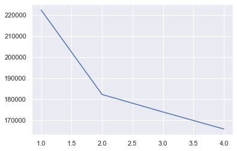

```python
y = np.array([i for i in range(1, 5, 1)])
plt.plot(y,cost)
```

#### 42. Combine

```python
income_cat = income_cat_copy.reset_index()
```

```python
clustersDf = pd.DataFrame(fitClusters_cao)
clustersDf.columns = ['cluster_predicted']
combinedDf = pd.concat([income_cat, clustersDf], axis=1).reset_index()
combinedDf = combinedDf.drop(['index','level_0'], axis =1)
```

```python
combinedDf.head()
```

|  | workclass | education | marital-status | occupation | relationship | race | sex | native-country | income | age_bin | cluster_predicted |
| --- | --- | --- | --- | --- | --- | --- | --- | --- | --- | --- | --- |
| 0 | Private | 11th | Never-married | Machine-op-inspct | Own-child | Black | Male | United-States | <=50K | 20-30 | 1 |
| 1 | Private | HS-grad | Married-civ-spouse | Farming-fishing | Husband | White | Male | United-States | <=50K | 30-40 | 0 |
| 2 | Local-gov | Assoc-acdm | Married-civ-spouse | Protective-serv | Husband | White | Male | United-States | >50K | 20-30 | 0 |
| 3 | Private | Some-college | Married-civ-spouse | Machine-op-inspct | Husband | Black | Male | United-States | >50K | 40-50 | 0 |
| 4 | ? | Some-college | Never-married | ? | Own-child | White | Female | United-States | <=50K | 0-20 | 1 |

#### 44. Cluster Identification :

```python
cluster_0 = combinedDf[combinedDf['cluster_predicted'] ==0]
cluster_1 = combinedDf[combinedDf['cluster_predicted'] ==1]
```

```python
cluster_0.info()
```

```
<class 'pandas.core.frame.DataFrame'>
Int64Index: 30766 entries, 1 to 48841
Data columns (total 11 columns):
 #   Column             Non-Null Count  Dtype
---  ------             --------------  -----
 0   workclass          30766 non-null  object
 1   education          30766 non-null  object
 2   marital-status     30766 non-null  object
 3   occupation         30766 non-null  object
 4   relationship       30766 non-null  object
 5   race               30766 non-null  object
 6   sex                30766 non-null  object
 7   native-country     30766 non-null  object
 8   income             30766 non-null  object
 9   age_bin            30766 non-null  category
 10  cluster_predicted  30766 non-null  uint16
dtypes: category(1), object(9), uint16(1)
memory usage: 2.4+ MB
```

```python
cluster_1.info()
```

```
<class 'pandas.core.frame.DataFrame'>
Int64Index: 18076 entries, 0 to 48840
Data columns (total 11 columns):
 #   Column             Non-Null Count  Dtype
---  ------             --------------  -----
 0   workclass          18076 non-null  object
 1   education          18076 non-null  object
 2   marital-status     18076 non-null  object
 3   occupation         18076 non-null  object
 4   relationship       18076 non-null  object
 5   race               18076 non-null  object
 6   sex                18076 non-null  object
 7   native-country     18076 non-null  object
 8   income             18076 non-null  object
 9   age_bin            18076 non-null  category
 10  cluster_predicted  18076 non-null  uint16
dtypes: category(1), object(9), uint16(1)
memory usage: 1.4+ MB
```

#### plotting again

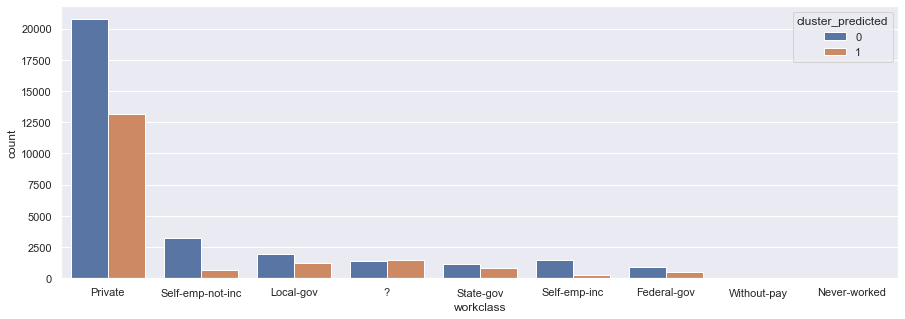

```python
#workclass
plt.subplots(figsize =(15,5))
sns.countplot(x=combinedDf['workclass'],
             order=combinedDf['workclass'].value_counts().index, hue=combinedDf['cluster_predicted'])
plt.show()
```

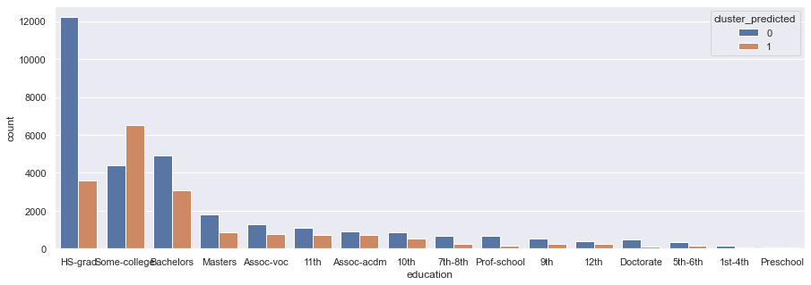

```python
#education
plt.subplots(figsize =(15,5))
sns.countplot(x=combinedDf['education'],
             order=combinedDf['education'].value_counts().index, hue=combinedDf['cluster_predicted'])
plt.show()
```

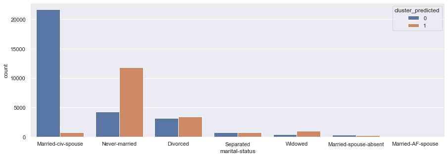

```python
#marital-status
plt.subplots(figsize =(15,5))
sns.countplot(x=combinedDf['marital-status'],
             order=combinedDf['marital-status'].value_counts().index, hue=combinedDf['cluster_predicted'])
plt.show()
```

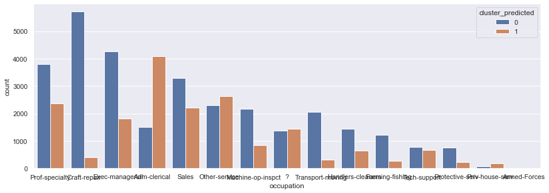

```python
#occupation
plt.subplots(figsize =(15,5))
sns.countplot(x=combinedDf['occupation'],
             order=combinedDf['occupation'].value_counts().index, hue=combinedDf['cluster_predicted'])
plt.show()
```

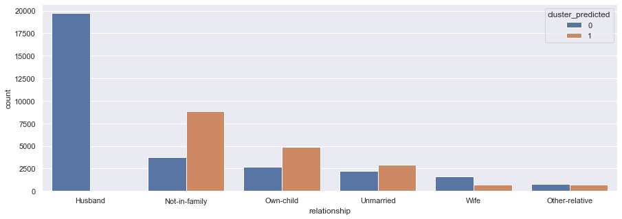

```python
#relationship
plt.subplots(figsize =(15,5))
sns.countplot(x=combinedDf['relationship'],
             order=combinedDf['relationship'].value_counts().index, hue=combinedDf['cluster_predicted'])
plt.show()
```

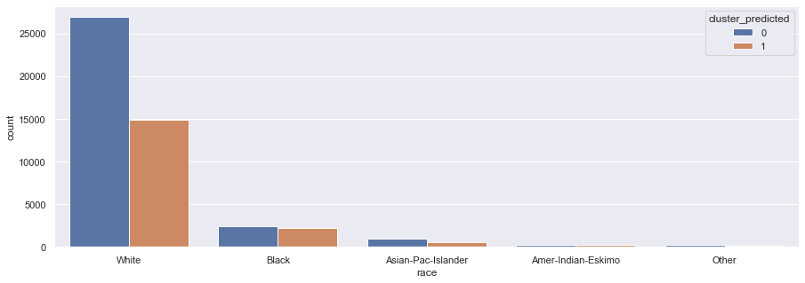

```python
#race
plt.subplots(figsize =(15,5))
sns.countplot(x=combinedDf['race'],
             order=combinedDf['race'].value_counts().index, hue=combinedDf['cluster_predicted'])
plt.show()
```

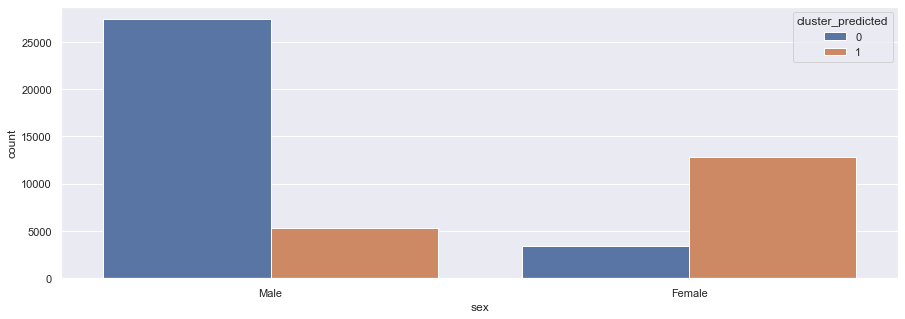

```python
#sex
plt.subplots(figsize =(15,5))
sns.countplot(x=combinedDf['sex'],
             order=combinedDf['sex'].value_counts().index, hue=combinedDf['cluster_predicted'])
plt.show()
```

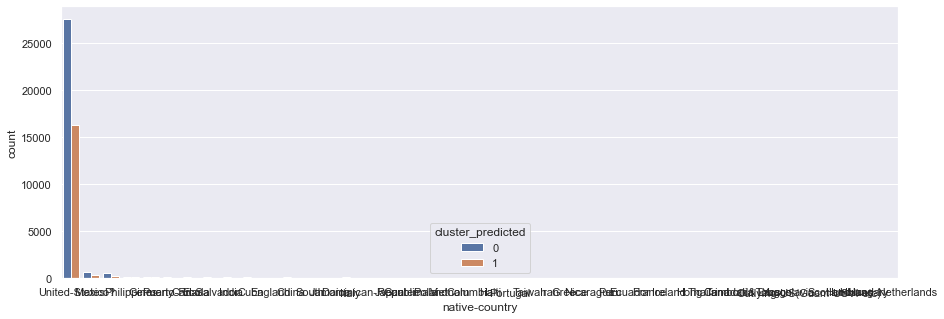

```python
#native-country
plt.subplots(figsize =(15,5))
sns.countplot(x=combinedDf['native-country'],
             order=combinedDf['native-country'].value_counts().index, hue=combinedDf['cluster_predicted'])
plt.show()
```

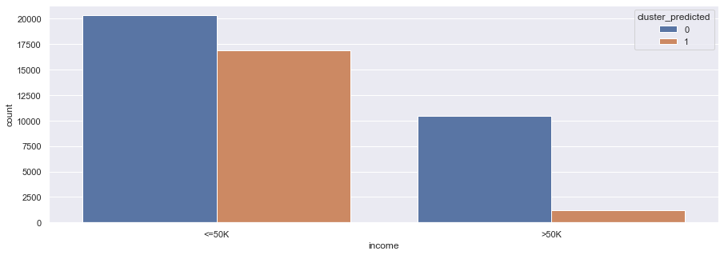

```python
#income
plt.subplots(figsize =(15,5))
sns.countplot(x=combinedDf['income'],
             order=combinedDf['income'].value_counts().index, hue=combinedDf['cluster_predicted'])
plt.show()
```

#### Kesimpulan dari dataset Income

#### Melakukan data preprocessing dari awal hingga akhir dan dibutuhkan plotting agar bisa mengetahu pembagian dari setiap cluster yang ada contohnya seperti cluster_predicted 0 dan clusters_predicted 1

### Kesimpulan

[output not shown]

```python
# Footer
myDate = datetime.datetime.now()
print("I certify that this is my own work.")
print("Signed by:")
print("Name: \t\t{}".format(myName))
print("NIM: \t\t{}".format(myNIM))
print("Time-stamp:\t{}".format(myDate))
```

```
I certify that this is my own work.
Signed by:
Name: 		Christopher Darren
NIM: 		00000054804
Time-stamp:	2023-04-29 18:57:19.572629
```

### Save the notebook, then convert the notebook to html (by running the next code).

```python
!jupyter nbconvert --to html "./IF540_Kelas EL_00000054804_Christopher Darren_Week09.ipynb" --output-dir="./"
```

```
[NbConvertApp] Converting notebook ./IF540_Kelas EL_00000054804_Christopher Darren_Week09.ipynb to html
[NbConvertApp] Writing 2499490 bytes to IF540_Kelas EL_00000054804_Christopher Darren_Week09.html
```